# Homework Sheet 5 – Regression modeling

39

Due: Wednesday, January 20 by 11:59 CET

# Instructions

**Important!** The `aida` package has been updated. Please run the following code to make sure your local version has these updates.

```r
remotes::install_github("michael-franke/aida-package")
```

- Create an Rmd-file with your group number (equivalent to StudIP group) in the ‘author’ heading and answer the following questions.
- When all answers are ready, ‘Knit’ the document to produce a HTML file.
- Create a ZIP archive called “IDA_HW05-Group-XYZ.zip” (where ‘XYZ’ is *your* group number) containing:
  - an R Markdown file “IDA_HW05-Group-XYZ.Rmd”
- a knitted HTML document “IDA_HW05-Group-XYZ.html”
- any other files necessary to compile your Rmarkdown to HTML (data, pictures etc.)
- Upload the ZIP archive on Stud.IP in your group folder before the deadline (see above). You may upload as many times as you like before the deadline, only your final submission will count.
- If you run `brms::brm` in an R code chunk, make sure to include `results='hide'` as an option to that code chunk to suppress the output of Stan.

# Exercise 1: Difference coding in Mental Chronometry [20 points]

The purpose of this exercise is to better understand coding schemes for categorical factors. We also would like to get more comfortable with testing hypotheses about regression coefficients in a Bayesian setting. Towards this end, we will construct a design matrix by hand to implement **simple difference coding**. We use the non-informative Bayesian regression model to efficiently sample from the posterior and test hypotheses about the Mental Chronometry data. In particular we are interested in the hypotheses spelled out in Appendix D.1.1.2 of the web-book, namely:

- mean reaction times are lower for data from the ‘reaction’ block than for the ‘goNoGo’ block
- mean reaction times are lower for data from the ‘goNoGo’ block than for the ‘discrimination’ block

## Ex 1.a Prepare data [1 point]

Create a variable `data_MC_excerpt` that contains all and only the relevant columns from the MC data set. The dependent variable should be the first column.

**Solution:**

```r
data_MC_excerpt <- aida::data_MC_cleaned %>%
  select(RT, block)
data_MC_excerpt
```

```
## # A tibble: 2,404 x 2
##       RT block
##    <dbl> <chr>
##  1   311 reaction
##  2   269 reaction
##  3   317 reaction
##  4   325 reaction
##  5   240 reaction
##  6   262 reaction
##  7   295 reaction
##  8   277 reaction
##  9   288 reaction
## 10   309 reaction
## # ... with 2,394 more rows
```

## Ex 1.b Get the empirical differences between means [2 points]

Compute the following differences:

1. the mean RT for condition `goNoGo` minus the mean RT for condition `reaction`
2. the mean RT for condition `discrimination` minus the mean RT for condition `goNoGo`

and store the result in the variables provided below (keep the brackets so that the values assigned show in the Rmarkdown output):

**Solution:**

```r
data_MC_summary <- data_MC_excerpt %>%
  group_by(block) %>%
  summarise(mean = mean(RT))
(data_MC_summary)
```

```
## # A tibble: 3 x 2
##   block           mean
##   <chr>          <dbl>
## 1 discrimination  488.
## 2 goNoGo          427.
## 3 reaction        300.
```

```r
(`goNoGo-reaction`       <-  data_MC_summary[2,2]-data_MC_summary[3,2])
```

```
##       mean
## 1 127.3806
```

```r
(`discrimination-goNoGo` <-  data_MC_summary[1,2]-data_MC_summary[2,2])
```

```
##       mean
## 1 60.41442
```

## Ex 1.c Build predictor matrix [5 points]

Add three columns to the data tibble `data_MC_excerpt`, like shown below. These columns should contain the numerical values to obtain so-called **simple difference coding** (as discussed in the initial video of Chapter 14, after ca. 10 minutes).

**Solution:**

```r
data_MC_excerpt <- data_MC_excerpt %>%
  group_by(block) %>%
  mutate(
    grand_mean  = 1,
    `goNoGo-reaction` = ifelse(block == "discrimination", -2/3, 1/3),
    `discrimination-goNoGo` = ifelse(block == "reaction", 2/3, -1/3)
  )
```

## Ex 1.d Run a Bayesian regression model [3 points]

Use the function `aida::get_samples_regression_noninformative` to obtain 10,000 samples from the posterior distribution for a standard linear regression model. (Hint: Use `as.matrix` to extract the predictor matrix from the tibble you created in the previous step.)

**Solution:**

```r
# leave out block col for matrix conversion since matrix values will be of
# type string instead of dbl otherwise
MC_matrix <- data_MC_excerpt[-2]
MC_matrix <- MC_matrix %>% as.matrix
input_MC <- MC_matrix[,2:4]
output_MC <- MC_matrix[,1]
samples <- aida::get_samples_regression_noninformative(input_MC, output_MC, n_samples=10000)
```

## Ex 1.e Summary statistics [2 point]

Use the function `aida::summarize_sample_vector` to show Bayesian summary statistics for the two most relevant parameters (given the hypotheses we are interested in for the Mental Chronometry experiment).

**Solution:**

```r
(samples %>%
    pull("goNoGo-reaction") %>%
    aida::summarize_sample_vector(., name="goNoGo-reaction"))
```

```
## # A tibble: 1 x 4
##   Parameter       `|95%`  mean `95%|`
##   <chr>            <dbl> <dbl>  <dbl>
## 1 goNoGo-reaction  -69.9 -60.4  -50.2
```

```r
(samples %>%
    pull("discrimination-goNoGo") %>%
    aida::summarize_sample_vector(., name="discrimination-goNoGo"))
```

```
## # A tibble: 1 x 4
##   Parameter             `|95%`  mean `95%|`
##   <chr>                  <dbl> <dbl>  <dbl>
## 1 discrimination-goNoGo  -137. -127.  -118.
```

## Ex 1.f Interpret your results [7 points]

Interpret these results using a Kruschke-style logic applied to (non-ROPEd) interval-based hypotheses. In doing so, state clearly what the coefficients encode, what the numerical results of the last step mean, and what you would conclude from all this regarding any potential evidence (or lack thereof) for or against the research hypotheses.

**Solution:**

- mean reaction time for ‘goNoGo’ minus the mean reaction time for ‘reaction’ is higher than 0
- mean reaction time for ‘discrimination’ minus the mean reaction time for ‘goNoGo’ is higher than 0

As we can clearly see that the additive inverse of the coefficients’ HDIs is completely contained in $(0, \infty)$, according to a Kruschke-style logic, we would **accept** both our formulated hypotheses.

# Exercise 2: Analyzing the King of France [28 points]

The purpose of this exercise is to practice with logistic regression and the interpretation of interaction terms. Thanks to those who took part, we have data from the King of France experiment from students of this class, so we can engage in “self-analysis”. If you want to understand what this experiment is about, read the relevant appendix chapter in the web-book.

We will be interested in the following research questions:

- **H1**: The latent probability of “TRUE” judgements is higher in C0 (with presupposition) than in C1 (where the presupposition is part of the at-issue / asserted content).
- **H2**: There is no difference in truth-value judgements between C0 (the positive sentence) and C6 (the negative sentence).
- **H3**: The disposition towards “TRUE” judgements is lower for C9 (where the presupposition is topical) than for C10 (where the presupposition is not topical and occurs under negation).

Load the data as follows (also applying some massaging, similar to what’s done in the web-book):

```r
IDA_data_KoF <- read_csv('data_KoF-IDA-2020.csv') %>%
  # discard practice trials
  filter(type != "practice") %>%
  mutate(
    # add a 'condition' variable
    condition = case_when(
      type == "special" ~ "background check",
      type == "main" ~ str_c("Condition ", condition),
      TRUE ~ "filler"
    ) %>%
      factor(
        ordered = T,
        levels = c(str_c("Condition ", c(0, 1, 6, 9, 10)), "background check", "filler")
      )
  ) %>%
  rename(correct_answer = correct)
IDA_data_KoF
```

```
## # A tibble: 2,040 x 23
##    submission_id QUD      RT   age comments condition correct_answer education
##            <dbl> <lgl> <dbl> <dbl> <chr>    <ord>     <lgl>          <chr>
##  1          1232 NA     3720    20 <NA>     filler    TRUE           Graduate~
##  2          1232 NA     4086    20 <NA>     filler    FALSE          Graduate~
##  3          1232 NA    16519    20 <NA>     Conditio~ FALSE          Graduate~
##  4          1232 NA     9623    20 <NA>     filler    TRUE           Graduate~
##  5          1232 NA     4845    20 <NA>     filler    TRUE           Graduate~
##  6          1232 NA     1877    20 <NA>     filler    TRUE           Graduate~
##  7          1232 NA    10454    20 <NA>     Conditio~ FALSE          Graduate~
##  8          1232 NA     4209    20 <NA>     filler    TRUE           Graduate~
##  9          1232 NA     5685    20 <NA>     Conditio~ FALSE          Graduate~
## 10          1232 NA    10530    20 <NA>     filler    TRUE           Graduate~
## # ... with 2,030 more rows, and 15 more variables: endTime <dbl>,
## #   experiment_id <dbl>, gender <chr>, languages <chr>, option1 <lgl>,
## #   option2 <lgl>, question <chr>, response <lgl>, startDate <chr>,
## #   startTime <dbl>, timeSpent <dbl>, trial_name <chr>, trial_number <dbl>,
## #   type <chr>, vignette <chr>
```

## Ex 2.a Clean the data [3 points]

Just like in the web-book we are going to clean the data by performing the following two steps in sequence:

1. Remove all data from any participant who got more than 50% of the answer to filler material wrong.
2. Remove individual main trials if the corresponding “background check” question was answered wrongly.

Use code from the web-book at will, but be mindful that you may have to make (minor) changes (e.g., variable naming).

Use R code to report how many participants (in Step 1) and trials (in step 2) are excluded.

**Solution:**

```r
#1
subject_error_rate <- IDA_data_KoF %>%
  # look at each participant in fillers only
  filter(condition == "filler") %>%
  group_by(submission_id) %>%
  # compute proportion of correct answers
  summarise(
    proportion_correct = mean(correct_answer == response),
    outlier_subject = proportion_correct < 0.5
  ) %>%
  arrange(proportion_correct) # keep only those who have TRUE boolean in proportion_correct
# keep only subjects who have a high enough subject_error_rate
d_cleaned <-
  full_join(IDA_data_KoF, subject_error_rate, by = "submission_id" ) %>%
  filter(outlier_subject == FALSE)
# Compute how many subjects were excluded
nrow(IDA_data_KoF) - nrow(subject_error_rate)
```

```
## [1] 1955
```

```r
#2
before_cleanse <- nrow(d_cleaned)
d_cleaned <- d_cleaned %>%
  filter(condition == "background check") %>%
  mutate(
    background_correct = correct_answer == response
  ) %>%
  select(submission_id, vignette, background_correct) %>%
  right_join(d_cleaned, by = c("submission_id", "vignette")) %>%
  # keep only the main trials which have a correct corresponding background check
  filter(type == "main" & background_correct == TRUE)

before_cleanse - nrow(d_cleaned)
```

```
## [1] 1677
```

## Ex 2.b Plot the data [2 points]

Plot the data just like in the the first part of the web-book’s appendix D4.4 (proportion per condition). Use the web-book code as much as you like while making any necessary amendments.

**Solution:**

```r
IDA_data_KoF_plot <- IDA_data_KoF %>%
  group_by(condition) %>%
  summarise(num_condition = n()) %>%
  mutate(proportion_condition = num_condition/nrow(IDA_data_KoF))
IDA_data_KoF_plot
```

```
## # A tibble: 7 x 3
##   condition        num_condition proportion_condition
##   <ord>                    <int>                <dbl>
## 1 Condition 0                 85               0.0417
## 2 Condition 1                 85               0.0417
## 3 Condition 6                 85               0.0417
## 4 Condition 9                 85               0.0417
## 5 Condition 10                85               0.0417
## 6 background check           425               0.208
## 7 filler                    1190               0.583
```

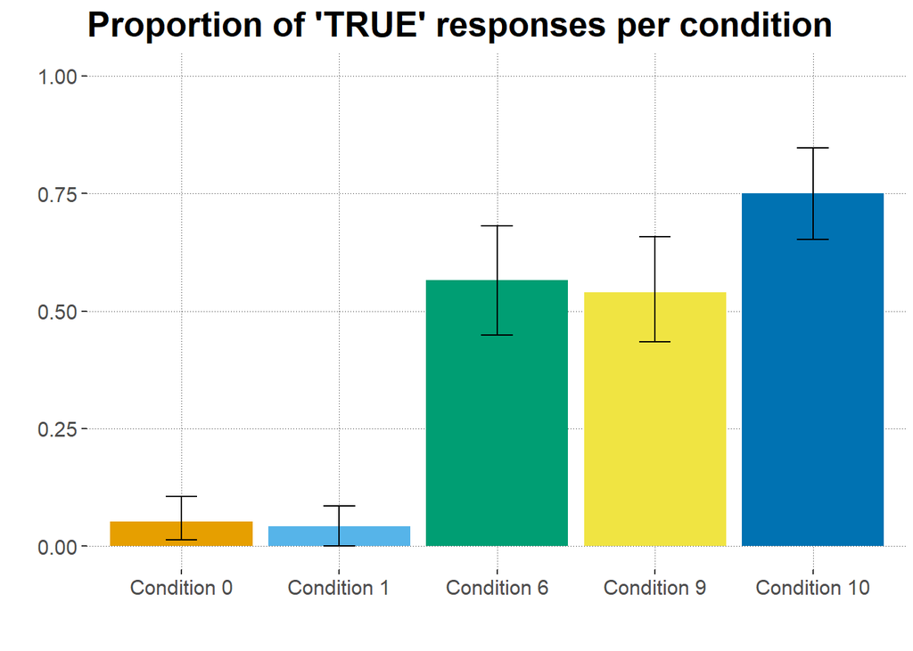

```r
d_cleaned %>%
  # drop unused factor levels
  droplevels() %>%
  # get means and 95% bootstrapped CIs for each condition
  group_by(condition) %>%
  nest() %>%
  summarise(
    CIs = map(data, function(d) bootstrapped_CI(d$response == "TRUE"))
  ) %>%
  unnest(CIs) %>%
  # plot means and CIs
  ggplot(aes(x = condition, y = mean, fill = condition)) +
  geom_bar(stat = "identity") +
  geom_errorbar(aes(ymin = lower, ymax = upper, width = 0.2)) +
  ylim(0,1) +
  ylab("") + xlab("") + ggtitle("Proportion of 'TRUE' responses per condition") +
  theme(legend.position = "none") +
  scale_fill_manual(values = project_colors)
```

## Ex 2.c Run logistic regression model [5 points]

Run a logistic regression model on the cleaned data, predicting `response` in terms of categorical factor `condition`. Make sure to also do the following:

- make the ordered factor `condition` a character vector before running the regression model
- change the non-informative default priors for all slope coefficients to a Student’s t distribution with 1 degree of freedom, a mean of 0 and a standard deviation of 2 (see web-book Chapter 13.4)
- set the flap `sample_prior = 'yes'` to also sample from the prior
- take 20,000 samples (using parameter `iter` in the function call of `brm`)

Finally, also add a call of `summary(...)` to show the summary of the fitted model in the Rmarkdown output.

**Solution:**

```r
#make the ordered factor 'condition' a character vector
d_cleaned <- d_cleaned %>%
  mutate(condition = as.character(condition))
d_cleaned

d_relevant <- d_cleaned %>%
  select(condition, response)
head(d_relevant,5)
kingOfFrance_fit = brm(
  formula = response ~ condition,
  family = bernoulli(link = "logit"),  # use Bernoulli as likelihood function because condition is a binary variable
  data = d_cleaned,
  prior = prior(student_t(1, 0, 2), class = 'b'),
  sample_prior = 'yes',
  iter = 20000
)
```

```r
summary(kingOfFrance_fit)$fixed[,c("l-95% CI", "Estimate", "u-95% CI")]
```

```
##                       l-95% CI   Estimate   u-95% CI
## Intercept            -3.681365 -2.6927458 -1.8619831
## conditionCondition1  -1.924667 -0.4811843  0.8432086
## conditionCondition10  2.776566  3.7811192  4.9084280
## conditionCondition6   1.968349  2.9336372  4.0282468
## conditionCondition9   1.876277  2.8295914  3.9055416
```

## Ex 2.d Test hypotheses [12 points]

Use the `brms::hypotheses` function to test the three hypotheses stated above. For each case interpret the results and formulate a conclusion such as “does/does not provide evidence” or “accept/reject hypothesis” according to the results.

### Hypothesis 1: C0 > C1

**Solution:**

```r
hypothesis(kingOfFrance_fit, "conditionCondition1 < 0")
```

```
## Hypothesis Tests for class b:
##                 Hypothesis Estimate Est.Error CI.Lower CI.Upper Evid.Ratio
## 1 (conditionConditi... < 0    -0.48       0.7    -1.67     0.63       3.07
##   Post.Prob Star
## 1      0.75
## ---
## 'CI': 90%-CI for one-sided and 95%-CI for two-sided hypotheses.
## '*': For one-sided hypotheses, the posterior probability exceeds 95%;
## for two-sided hypotheses, the value tested against lies outside the 95%-CI.
## Posterior probabilities of point hypotheses assume equal prior probabilities.
```

**Solution** With an evidence ratio of ~3 and a posterior probability of ~0.75, our model provides only very weak evidence in favor of the hypothesis. In this case, withholding judgement about the hypothesis is probably wisest.

### Hypothesis 2: C0 = C6

**Solution:**

```r
hypothesis(kingOfFrance_fit, "conditionCondition6 = 0")
```

```
## Hypothesis Tests for class b:
##                 Hypothesis Estimate Est.Error CI.Lower CI.Upper Evid.Ratio
## 1 (conditionConditi... = 0     2.93      0.53     1.97     4.03          0
##   Post.Prob Star
## 1         0    *
## ---
## 'CI': 90%-CI for one-sided and 95%-CI for two-sided hypotheses.
## '*': For one-sided hypotheses, the posterior probability exceeds 95%;
## for two-sided hypotheses, the value tested against lies outside the 95%-CI.
## Posterior probabilities of point hypotheses assume equal prior probabilities.
```

**Solution** With an evidence ratio and posterior probability of 0 for the hypothesis, the model does provide decisive evidence for rejecting our hypothesis.

### Hypothesis 3: C9 < C10

**Solution:**

```r
hypothesis(kingOfFrance_fit, "conditionCondition9 < conditionCondition10")
```

```
## Hypothesis Tests for class b:
##                 Hypothesis Estimate Est.Error CI.Lower CI.Upper Evid.Ratio
## 1 (conditionConditi... < 0    -0.95      0.36    -1.54    -0.37     299.75
##   Post.Prob Star
## 1         1    *
## ---
## 'CI': 90%-CI for one-sided and 95%-CI for two-sided hypotheses.
## '*': For one-sided hypotheses, the posterior probability exceeds 95%;
## for two-sided hypotheses, the value tested against lies outside the 95%-CI.
## Posterior probabilities of point hypotheses assume equal prior probabilities.
```

**Solution** With an evidence ratio of ~300 and posterior probability of 1 for the hypothesis, the model does provide decisive evidence for accepting our hypothesis.

## Ex 2.e Interaction with `gender` [6 points]

Let’s get nasty! Let’s do what no good scientist should ever do. (We do it for practice and for rubbing it in that this is NOT what you should EVER do.)

Suppose we did not like the outcome of the test for H1 above. So we are going to run a new analysis (for which there is no *prima facie* rationale) just to see if we cannot possibly squeeze out something that looks like an argument for the conclusion that we so crave to be supported. Worst of all, we stipulate -completely out of the blue- a potential gender effect on the understanding of linguistic presupposition (say what?).

Obviously, what this exercise is really after is getting practice with interpreting *interaction terms* for categorical regression. So, look at the code below, try to understand what it does and then inspect the summary of the model fit shown here. Then answer the following question: based on this analysis and results shown in the summary, is there any reason to believe that (i) there is a difference in the answer behavior between self-identified male and self-identified female participants (i.e., is there a main effect of `gender`?), and (ii) is there any specific way in which gender impacts on the disposition to select “TRUE” in either of the two conditions (i.e., is there an interaction?). Identify the source of your conclusion by pointing out which numbers (or whatever) you draw on in the summary of the model fit.

```r
IDA_data_KoF_interaction <- IDA_data_KoF %>%
  filter(condition %in% c("Condition 0", "Condition 1")) %>%
  filter(!is.na(gender)) %>%
  mutate(
    gender = factor(gender)
  ) %>%
  droplevels() %>%
  select(response, condition, gender)

# apply 'sum' contrasts
contrasts(IDA_data_KoF_interaction$condition) <- contr.sum(2)
contrasts(IDA_data_KoF_interaction$gender) <- contr.sum(2)
# add intelligible name to the new contrast coding
colnames(contrasts(IDA_data_KoF_interaction$condition)) <- ":Cond1"
colnames(contrasts(IDA_data_KoF_interaction$gender)) <- ":male"
fit_brms_KoF_interaction <- brm(
  # predict `response` in terms of `condition`
  formula = response ~ condition * gender,
  # specify which data to use
  data = IDA_data_KoF_interaction,
  # logistic regression
  family = bernoulli(link = "logit"),
  # weakly informative priors (slightly conservative)
  #   for `class = 'b'` (i.e., all slopes)
  prior = prior(student_t(1, 0, 2),  class = 'b'),
  # also collect samples from the prior (for point-valued testing)
  sample_prior = 'yes',
  # take more than the usual samples (for numerical stability of testing)
  iter = 20000
)
```

```r
summary(fit_brms_KoF_interaction)
```

```
##  Family: bernoulli
##   Links: mu = logit
## Formula: response ~ condition * gender
##    Data: IDA_data_KoF_interaction (Number of observations: 162)
## Samples: 4 chains, each with iter = 20000; warmup = 10000; thin = 1;
##          total post-warmup samples = 40000
##
## Population-Level Effects:
##                             Estimate Est.Error l-95% CI u-95% CI Rhat Bulk_ESS
## Intercept                      -3.00      0.37    -3.78    -2.32 1.00    33683
## condition:Cond1                 0.12      0.36    -0.59     0.85 1.00    32339
## gender:male                    -0.22      0.36    -0.95     0.48 1.00    31282
## condition:Cond1:gender:male    -0.12      0.36    -0.84     0.57 1.00    34754
##                             Tail_ESS
## Intercept                      27059
## condition:Cond1                27076
## gender:male                    28612
## condition:Cond1:gender:male    28143
##
## Samples were drawn using sampling(NUTS). For each parameter, Bulk_ESS
## and Tail_ESS are effective sample size measures, and Rhat is the potential
## scale reduction factor on split chains (at convergence, Rhat = 1).
```

**Solution:**

#### Hypothesis (i):

```r
brms::hypothesis(fit_brms_KoF_interaction, "gender:male < 0" )
```

```
## Hypothesis Tests for class b:
##          Hypothesis Estimate Est.Error CI.Lower CI.Upper Evid.Ratio Post.Prob
## 1 (gender:male) < 0    -0.22      0.36    -0.82     0.37       2.78      0.74
##   Star
## 1
## ---
## 'CI': 90%-CI for one-sided and 95%-CI for two-sided hypotheses.
## '*': For one-sided hypotheses, the posterior probability exceeds 95%;
## for two-sided hypotheses, the value tested against lies outside the 95%-CI.
## Posterior probabilities of point hypotheses assume equal prior probabilities.
```

The evidence ratio and the posterior probability are both low. This means that the data provide very weak evidence in favor of the existence for a main effect of gender.

#### Hypothesis (ii):

```r
(brms::hypothesis(fit_brms_KoF_interaction, "condition:Cond1:gender:male = 0" ))
```

```
## Hypothesis Tests for class b:
##                 Hypothesis Estimate Est.Error CI.Lower CI.Upper Evid.Ratio
## 1 (condition:Cond1:... = 0    -0.12      0.36    -0.84     0.57       1.23
##   Post.Prob Star
## 1      0.55
## ---
## 'CI': 90%-CI for one-sided and 95%-CI for two-sided hypotheses.
## '*': For one-sided hypotheses, the posterior probability exceeds 95%;
## for two-sided hypotheses, the value tested against lies outside the 95%-CI.
## Posterior probabilities of point hypotheses assume equal prior probabilities.
```

```r
(brms::hypothesis(fit_brms_KoF_interaction, "condition:Cond1:gender:male > 0" ))
```

```
## Hypothesis Tests for class b:
##                 Hypothesis Estimate Est.Error CI.Lower CI.Upper Evid.Ratio
## 1 (condition:Cond1:... > 0    -0.12      0.36    -0.72     0.46       0.58
##   Post.Prob Star
## 1      0.37
## ---
## 'CI': 90%-CI for one-sided and 95%-CI for two-sided hypotheses.
## '*': For one-sided hypotheses, the posterior probability exceeds 95%;
## for two-sided hypotheses, the value tested against lies outside the 95%-CI.
## Posterior probabilities of point hypotheses assume equal prior probabilities.
```